# Meta-Analysis Workshop Software Workflow Version 1.0

Author

Alex Shaw

## About this workflow

This is the software workflow for our Introduction to Meta-Analysis workshop. The slides for the presentation accompanying this workflow can be found [here](https://sydney-informatics-hub.github.io/stats-resources/specialist_statistics.html#meta-analysis-an-introduction).

In this workflow we focus on practical data analysis by presenting the steps to run a meta-analysis using the `metafor` package in R. The R code used to create output is also included.

## Acknowledgements

If you use this workflow, please don’t forget to acknowledge us. You can use the following sentence

> The authors acknowledge the Statistical Workshops and Workflows provided by the Sydney Informatics Hub, a Core Research Facility of the University of Sydney

This data is taken from the book “[Methods of Meta-analysis in Medical Research](https://sydney.primo.exlibrisgroup.com/permalink/61USYD_INST/14vvljs/alma991008397859705106)” by A. J. Sutton (originally extracted from the article: [Smith, George Davey, Fujian Song, and Trevor A Sheldon. “Cholesterol Lowering and Mortality: The Importance of Considering Initial Level of Risk.”](https://sydney.primo.exlibrisgroup.com/permalink/61USYD_INST/1367smt/cdi_gale_infotracacademiconefile_A13991531) British Medical Journal 306.6889 (1993): 1367–. Print.)

The data comprises 34 studies assessing the effectiveness of cholesterol treatments on mortality in randomised controlled trials.

### Step 1: R setup

Before we delve into the content, it is necessary to load certain libraries. If you want to use them, please install them beforehand with `install.packages("library_name")`.

```r
# Run once
# install.packages("metafor")

library(metafor)
```

Load the data. Note: check file is in your working directory.

```r
metadata <- read.csv("Meta_Sutton_Smith.csv", header = T)
head(metadata)
```

```
  Sutton.et.al   author year g1.r1 g1.r0 g1.n g0.r1 g0.r0 g0.n
1            1 author 1 1992    28   176  204    51   151  202
2            2 author 2 1962    70   215  285    38   109  147
3            3 author 3 1963    37   119  156    40    79  119
4            4 author 4 1981     2    86   88     3    27   30
5            5 author 5 1969     0    30   30     3    30   33
6            6 author 6 1988    61   218  279    82   194  276
```

### Step 2: Calculate effect sizes using escalc()

This function creates variables for `yi` which is the effect size, and `vi` which is the variance of yi. These are added to the metadata object dataframe.

Tell the function what effect size to calculate using measure=“OR”,“RR”,“RD”, etc.

We can only choose a measure that matches our data - i.e. it has a binary outcome.

```r
meta.es <-
  escalc(measure = "OR", g1.r1, g1.r0, g0.r1, g0.r0, data = metadata)

head(meta.es)
```

```
  Sutton.et.al   author year g1.r1 g1.r0 g1.n g0.r1 g0.r0 g0.n      yi     vi
1            1 author 1 1992    28   176  204    51   151  202 -0.7528 0.0676
2            2 author 2 1962    70   215  285    38   109  147 -0.0684 0.0544
3            3 author 3 1963    37   119  156    40    79  119 -0.4876 0.0731
4            4 author 4 1981     2    86   88     3    27   30 -1.5640 0.8820
5            5 author 5 1969     0    30   30     3    30   33 -1.9459 2.3513
6            6 author 6 1988    61   218  279    82   194  276 -0.4125 0.0383
```

We use the `escalc` function from metafor to create `yi` which is the log OR effect size and `vi` which is the variance of `yi`.

When we view the model object `meta.es`, the effect size and variance sit alongside our inputs.

### Step 3: create a meta-analysis summary using rma()

```r
meta.re <- rma(yi, vi, data = meta.es) #REML estimation by default

# Use the method argument to change estimation to Der Simonian and Laird, etc.
# for example: meta.reDL <-rma(yi, vi, data = meta.es, method = "DL")
# Now convert summary estimate log(OR) to OR
meta.re.or <- exp(c(meta.re$b, meta.re$ci.lb, meta.re$ci.ub))
summary(meta.re)
```

```
Random-Effects Model (k = 34; tau^2 estimator: REML)

  logLik  deviance       AIC       BIC      AICc
-22.9313   45.8625   49.8625   52.8556   50.2625

tau^2 (estimated amount of total heterogeneity): 0.0478 (SE = 0.0269)
tau (square root of estimated tau^2 value):      0.2186
I^2 (total heterogeneity / total variability):   53.87%
H^2 (total variability / sampling variability):  2.17

Test for Heterogeneity:
Q(df = 33) = 89.1065, p-val < .0001

Model Results:

estimate      se     zval    pval    ci.lb   ci.ub
 -0.1178  0.0628  -1.8750  0.0608  -0.2410  0.0053  .

---
Signif. codes:  0 '***' 0.001 '**' 0.01 '*' 0.05 '.' 0.1 ' ' 1
```

```r
# Print OR results
cat("Odds Ratio (OR):", round(meta.re.or[1], 3), "\n","95% CI: [", round(meta.re.or[2], 3), ",", round(meta.re.or[3], 3), "]\n")
```

```
Odds Ratio (OR): 0.889
 95% CI: [ 0.786 , 1.005 ]
```

```r
# For a fixed effects model, use method="FE"
meta.fe <- rma(yi, vi, data = meta.es, method = "FE")
summary(meta.fe)
```

```
Fixed-Effects Model (k = 34)

  logLik  deviance       AIC       BIC      AICc
-41.3091   89.1065   84.6181   86.1445   84.7431

I^2 (total heterogeneity / total variability):   62.97%
H^2 (total variability / sampling variability):  2.70

Test for Heterogeneity:
Q(df = 33) = 89.1065, p-val < .0001

Model Results:

estimate      se     zval    pval    ci.lb    ci.ub
 -0.1691  0.0324  -5.2258  <.0001  -0.2325  -0.1057  ***

---
Signif. codes:  0 '***' 0.001 '**' 0.01 '*' 0.05 '.' 0.1 ' ' 1
```

```r
# Now convert summary estimate log(OR) to OR
meta.fe.or <- exp(c(meta.fe$b, meta.fe$ci.lb, meta.fe$ci.ub))

cat("Odds Ratio (OR):", round(meta.fe.or[1], 3), "95% CI: [", round(meta.fe.or[2], 3), ",", round(meta.fe.or[3], 3), "]\n")
```

```
Odds Ratio (OR): 0.844 95% CI: [ 0.793 , 0.9 ]
```

Random-Effects model has

- Reduced OR Effect size from 0.84 to 0.89 (closer to 1)
- Increased width of CI from 0.79~0.90 to 0.79~1.01
- CI for effect size now traverses 1.00 (just)

### Create Forest Plots

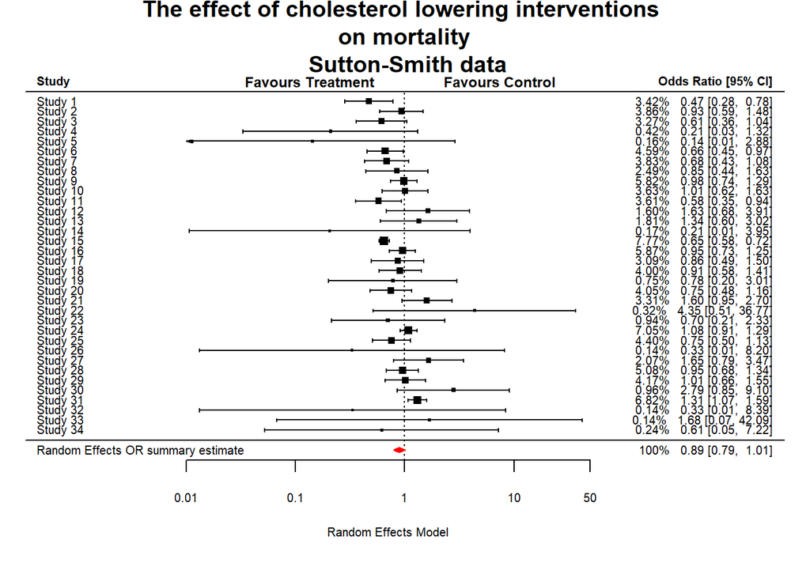

```r
# Create Forest Plots
# First plot is for Random-Effects model
forest(
  meta.re,
  header = TRUE,
  atransf = exp, #display OR on x-axis log scale
  at = log(c(0.01, 0.1, 1, 10,50)),
  xlim = c(-8, 8),
  xlab = "Random Effects Model",
  mlab = "Random Effects OR summary estimate",
  showweights = TRUE,
  pch = 15,
  border = "red",  #colour of summary diamond border
  col = "red",     #colour of summary diamond fill
  main = "The effect of cholesterol lowering interventions \n on mortality \n Sutton-Smith data"
)
op <- par(cex = 0.75, font = 2)
text(c(-2, 2), 36, c("Favours Treatment", "Favours Control"))
```

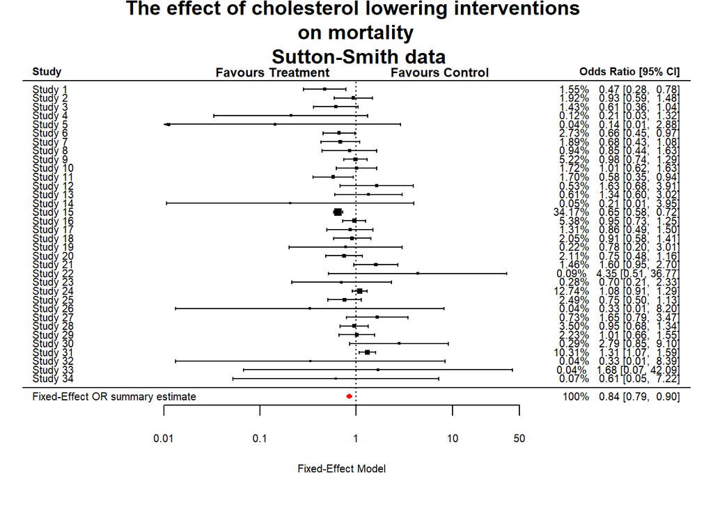

```r
par(op)

# Second plot for Fixed-Effect model
forest(
  meta.fe,
  header = TRUE,
  atransf = exp, #display OR on x-axis log scale
  at = log(c(0.01, 0.1, 1, 10, 50)),
  xlim = c(-8, 8),
  xlab = "Fixed-Effect Model",
  mlab = "Fixed-Effect OR summary estimate",
  showweights = TRUE,
  pch = 15,
  border = "red",  #colour of summary diamond border
  col = "red",     #colour of summary diamond fill
  main = "The effect of cholesterol lowering interventions \n on mortality \n Sutton-Smith data"
)
op <- par(cex = 0.75, font = 2)
text(c(-2, 2), 36, c("Favours Treatment", "Favours Control"))
```

```r
par(op)
```

- Note estimates and CI’s for each study. Each study’s weight designated by size of square.
- Graphical representation of (moderate) heterogeneity.
- Weightings are different between the two models

### Step 4: Explore Heterogeneity

Refer to the output from the rma() function for both models.

No additional code required.

- Q statistic is significant p<0.0001 (heterogeneous studies)
- I squared (proportion of inconsistency) 54%~63% is moderate
- Tau squared estimate is > zero
- We expect studies to have underlying differences in effect size
- We should use random effects

### Step 5: Publication Bias

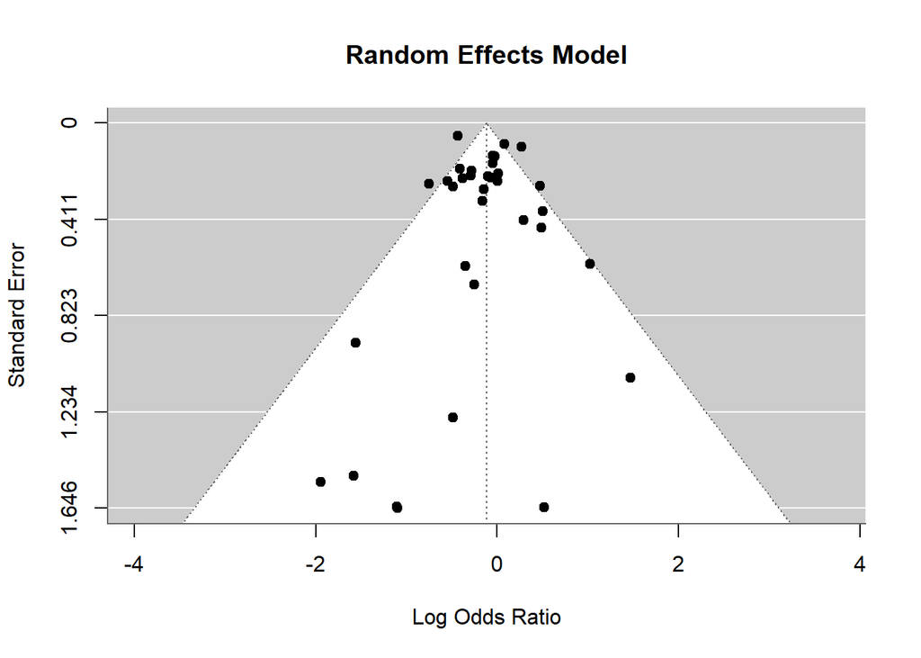

```r
# Basic Funnel Plot

funnel(meta.re, main = "Random Effects Model")
```

```r
# We can use trimfill(), ranktest(), regtest(), hc() as tests for bias
# Use the trimfill() function to see where "missing" studies might be
```

Check for asymmetry * No of studies > 10 * Studies are of various sizes and precision * Plot appears to be symmetrical (can use random effects model without problem) * One more check

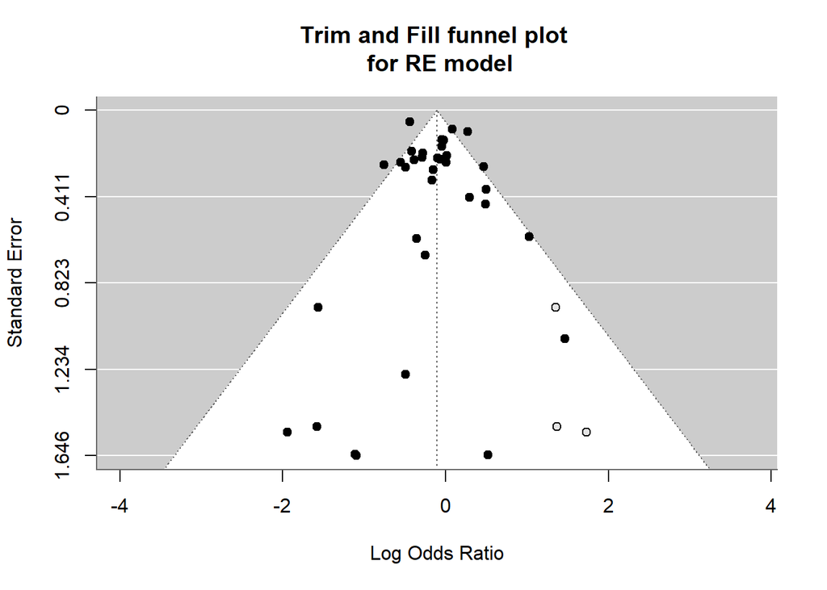

```r
meta.tf <- trimfill(meta.re)
funnel(meta.tf, main = "Trim and Fill funnel plot \n for RE model")
```

Note: 3 imputed studies (open circles)

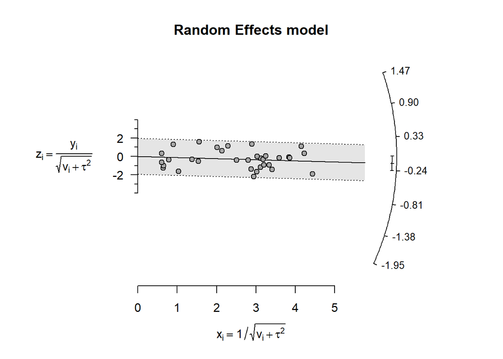

```r
# Other diagnostic plots like Radial (Galbraith) plot are available
# aslo labbe(), qqnorm(), baujat(), gosh()

# lets look at the Radial plots
radial(meta.re, main = "Random Effects model")
```

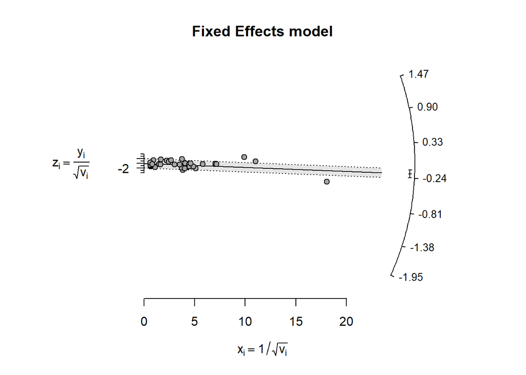

```r
radial(meta.fe, main = "Fixed Effects model")
```

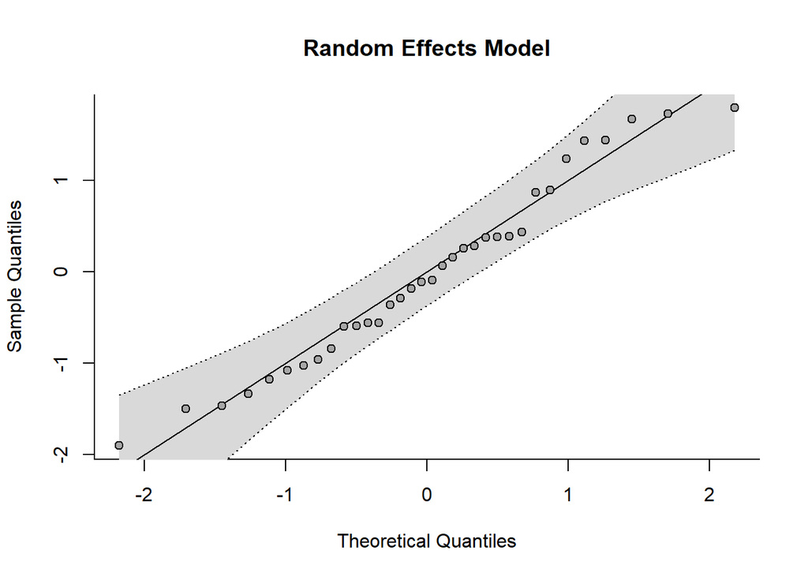

```r
# lets look at some Q-Q plots
qqnorm(meta.re, main = "Random Effects Model")
```

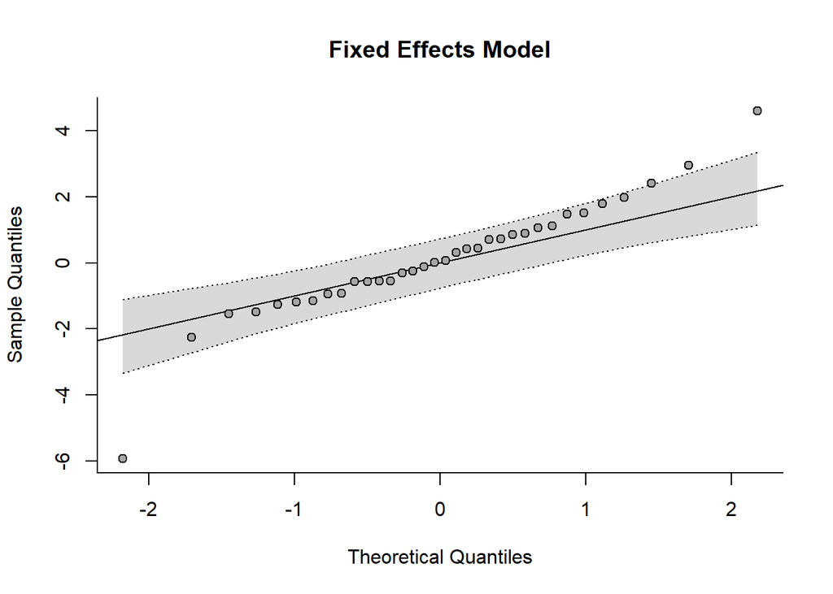

```r
qqnorm(meta.fe, main = "Fixed Effects Model")
```

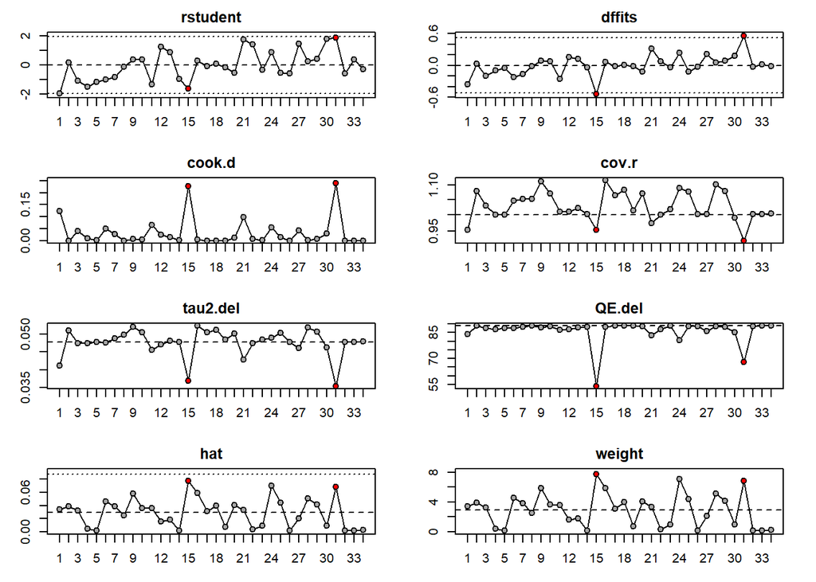

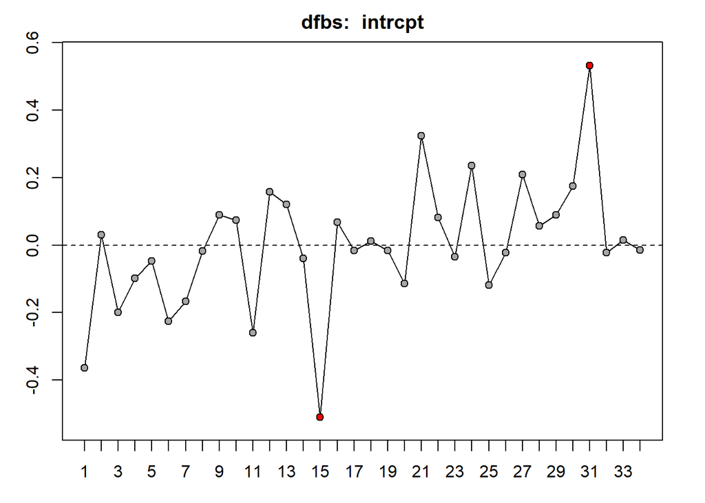

```r
# Can also produce influence statistics
infl <- influence(meta.re)
plot(infl, plotdfb = TRUE)
```

### Step 6: Sub-group analysis (not included for this example)

The original study looked at a sub-group analysis using the factor: Coronary heart disease risk group – high, medium, low

Sub-group analysis found significant differences between these groups, with only the high risk CHD (treatment) group showing a benefit in terms of total mortality.

A meta-regression was also carried out showing a similar trend.

### Final Step: report your meta-analysis